# Visualize chromatin state transitions

A chromatin state transition matrix shows how much the chromatin state in the genome has been changed from e.g. one sample to another. In our [recent paper](http://msb.embopress.org/content/12/3/861) we demonstrated how chromatin states change between smoking people and non-smoking people by means of [Chord Diagram](http://d3dwu2jylmmhzr.cloudfront.net/content/msb/12/3/861/F8.large.jpg). In this post, I will demonstrate how to make such plot by the **circlize** package and enhance it by adding methylation information.

The data demonstrated in this post is processed from [Roadmap data](http://www.roadmapepigenomics.org/). The chromatin states [are learned from five core chromatin marks](http://egg2.wustl.edu/roadmap/web_portal/chr_state_learning.html#core_15state). Roadmap samples are separated into two groups based on expression profile. In each group, a chromatin state is assigned to the corresponding genomic bin if it is recurrent in at least half of the samples.

The processed data is stored as chromatin_transition.RData.

```r
library(circlize)
load("../data/chromatin_transition.RData")
```

There are three matrix: `mat`, `meth_mat_1` and `meth_mat_2` which are:

- `mat`: chromatin state transition matrix. Rows correspond to states in group 1 and columns correspond to group 2. The value in the matrix are total base pairs that transite from one group to the other. E.g. there are in total 79600 bp which are in “TssA” state in group 1 and they change to “TssAFlnk” state in group 2. On the digonal are the unchanged states.
- `meth_mat_1`: mean methylation in group 1 in each category.
- `meth_mat_2`: mean methylation in group 2 in each category.

```r
mat[1:4, 1:4]
```

```
##            TssA TssAFlnk TxFlnk     Tx
## TssA     497200    79600  13400   1800
## TssAFlnk  56400   233200   5000    800
## TxFlnk        0      400  43000   1800
## Tx          800      200    200 166400
```

```r
meth_mat_1[1:4, 1:4]
```

```
##               TssA  TssAFlnk    TxFlnk        Tx
## TssA     0.1647232 0.1580874 0.1917435 0.2690045
## TssAFlnk 0.2591677 0.2689880 0.3616242 0.3411387
## TxFlnk          NA 0.3697514 0.3360386 0.4752722
## Tx       0.8268626 0.7822987 0.5799682 0.6595322
```

Normally, majority in the genome are unchanged states, thus, we should only look at the regions in which their states are changed.

```r
# proportion of the unchanges states in the genome
sum(diag(mat))/sum(mat)
```

```
## [1] 0.6192262
```

```r
# remove the unchanged states
diag(mat) = 0
```

When making the plot, actually rows and columns are different (because one is from group 1 and the other is from group 2), thus we give them different names and the original names are stored in `all_states`.

```r
all_states = rownames(mat)
n_states = nrow(mat)

rownames(mat) = paste0("R_", seq_len(n_states))
colnames(mat) = paste0("C_", seq_len(n_states))

dimnames(meth_mat_1) = dimnames(mat)
dimnames(meth_mat_2) = dimnames(mat)
```

```r
state_col = c("TssA" = "#E41A1C",
              "TssAFlnk" = "#E41A1C",
              "TxFlnk" = "#E41A1C",
              "Tx" = "#E41A1C",
              "TxWk" = "#E41A1C",
              "EnhG" = "#E41A1C",
              "Enh" = "#E41A1C",
              "ZNF/Rpts" = "#E41A1C",
              "Het" = "#377EB8",
              "TssBiv" = "#377EB8",
              "BivFlnk" = "#377EB8",
              "EnhBiv" = "#377EB8",
              "ReprPC" = "#377EB8",
              "ReprPCWk" = "#377EB8",
              "Quies" = "black")

# one for rows and one for columns
state_col2 = c(state_col, state_col)
names(state_col2) = c(rownames(mat), colnames(mat))

colmat = rep(state_col2[rownames(mat)], n_states)
colmat = rgb(t(col2rgb(colmat)), maxColorValue = 255)

qati = quantile(mat, 0.7)
colmat[mat > qati] = paste0(colmat[mat > qati], "A0")
colmat[mat <= qati] = paste0(colmat[mat <= qati], "20")
dim(colmat) = dim(mat)
```

Now we can use `chordDiagram()` function to make the plot. Here we set one pre-allocated track in which the methylation information will be put.

`chordDiagram()` returns a data frame which contains coordinates for all links which will be used later.

`de` is the degree for the “gap” between group 1 and group 2.

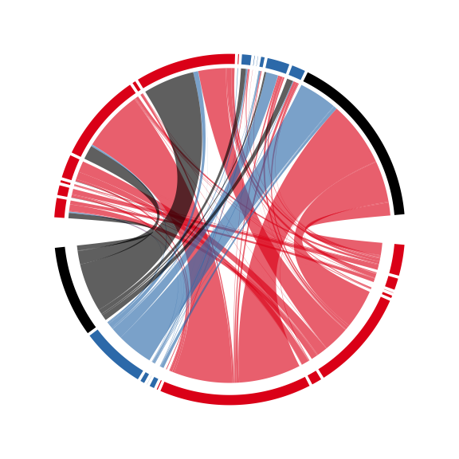

```r
de = 360 - (360 - 20 - 30) - 30
circos.par(start.degree = -de/4, gap.degree = c(rep(1, n_states-1), de/2, rep(1, n_states-1), de/2))

cdm_res = chordDiagram(mat, col = colmat, grid.col = state_col2,
    directional = TRUE, annotationTrack = "grid", preAllocateTracks = list(track.height = 0.1))
```

If the degree for a sector is larger than 3 degrees, the index for the state and axis is added. Note since there is already one pre-allocated track, the circular rectangles are in the second track (`track.index = 2`).

```r
for(sn in get.all.sector.index()) {
    if(abs(get.cell.meta.data("cell.start.degree", sector.index = sn) -
           get.cell.meta.data("cell.end.degree", sector.index = sn)) > 3) {
        xcenter = get.cell.meta.data("xcenter", sector.index = sn, track.index = 2)
        ycenter = get.cell.meta.data("ycenter", sector.index = sn, track.index = 2)
        i_state = as.numeric(gsub("(C|R)_", "", sn))
        circos.text(xcenter, ycenter, i_state, col = "white", font = 2, cex = 0.7,
            sector.index = sn, track.index = 2, adj = c(0.5, 0.5), niceFacing = TRUE)
        circos.axis(sector.index = sn, track.index = 2, major.tick.percentage = 0.2,
            labels.away.percentage = 0.2, labels.cex = 0.5)
    }
}
```

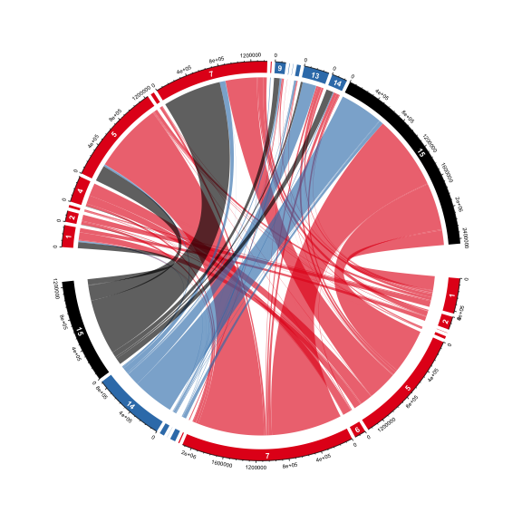

On the top half, it is easy to see the proportion of different transitions in group 1 that come to every state in group 2. However, it is not straightforward for the states in the bottom half to see the proportion of different states in group 2 they transite to. This can be solved by adding small circular rectangles. In following example, the newly added circular rectangles in the bottom half shows e.g. how much the state 15 in group 1 has been transited to different states in group 2.

```r
for(i in seq_len(nrow(cdm_res))) {
    if(cdm_res$value[i] > 0) {
        circos.rect(cdm_res[i, "x1"], -0.5, cdm_res[i, "x1"] - abs(cdm_res[i, "value"]), -0.7,
            col = state_col2[cdm_res$cn[i]], border = state_col2[cdm_res$cn[i]],
            sector.index = cdm_res$rn[i], track.index = 2)
    }
}
```

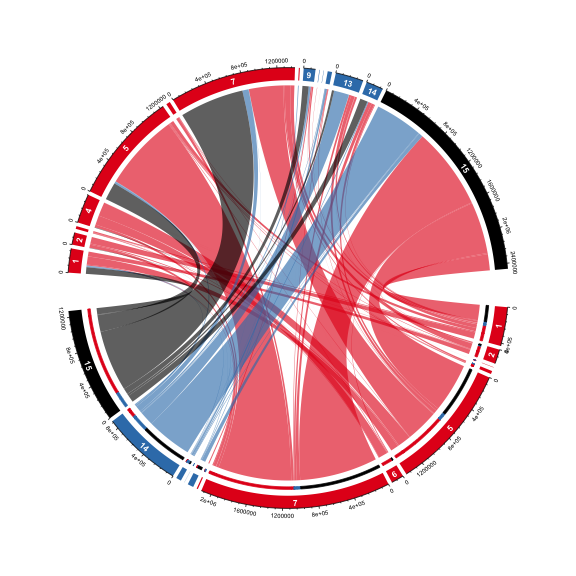

Methylation in each category is put on the most outside of the circle. On this track, we will put two paralle rectangles which are mean methylation and methylation difference between group 1 and group 2. Basically, on the bottom, we show `meth_mat_2 - meth_mat_1` and on the top we show `meth_mat_1 - meth_mat_2`.

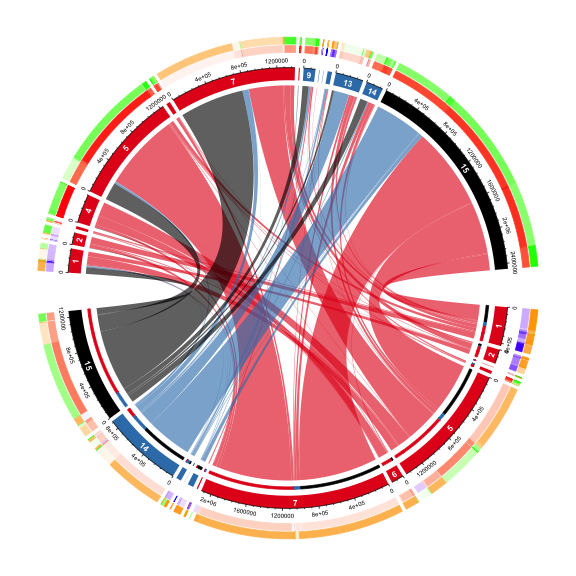

```r
abs_max = quantile(abs(c(meth_mat_1, meth_mat_2) - 0.5), 0.95, na.rm = TRUE)
col_fun = colorRamp2(c(0.5 - abs_max, 0.5, 0.5 + abs_max), c("blue", "white", "red"))
col_fun2 = colorRamp2(c(-abs_max, 0, abs_max), c("green", "white", "orange"))

ylim = get.cell.meta.data("ylim", sector.index = rownames(mat)[1], track.index = 1)
y1 = ylim[1] + (ylim[2] - ylim[1])*0.4
y2 = ylim[2]
for(i in seq_len(nrow(cdm_res))) {
    if(cdm_res$value[i] > 0) {
        circos.rect(cdm_res[i, "x1"], y1, cdm_res[i, "x1"] - abs(cdm_res[i, "value"]), y1 + (y2-y1)*0.45,
            col = col_fun(meth_mat_1[cdm_res$rn[i], cdm_res$cn[i]]),
            border = col_fun(meth_mat_1[cdm_res$rn[i], cdm_res$cn[i]]),
            sector.index = cdm_res$rn[i], track.index = 1)

        circos.rect(cdm_res[i, "x1"], y1 + (y2-y1)*0.55, cdm_res[i, "x1"] - abs(cdm_res[i, "value"]), y2,
            col = col_fun2(meth_mat_2[cdm_res$rn[i], cdm_res$cn[i]] - meth_mat_1[cdm_res$rn[i], cdm_res$cn[i]]),
            border = col_fun2(meth_mat_2[cdm_res$rn[i], cdm_res$cn[i]] - meth_mat_1[cdm_res$rn[i], cdm_res$cn[i]]),
            sector.index = cdm_res$rn[i], track.index = 1)

        circos.rect(cdm_res[i, "x2"], y1, cdm_res[i, "x2"] - abs(cdm_res[i, "value"]), y1 + (y2-y1)*0.45,
            col = col_fun(meth_mat_2[cdm_res$rn[i], cdm_res$cn[i]]),
            border = col_fun(meth_mat_2[cdm_res$rn[i], cdm_res$cn[i]]),
            sector.index = cdm_res$cn[i], track.index = 1)

        circos.rect(cdm_res[i, "x2"], y1 + (y2-y1)*0.55, cdm_res[i, "x2"] - abs(cdm_res[i, "value"]), y2,
            col = col_fun2(meth_mat_1[cdm_res$rn[i], cdm_res$cn[i]] - meth_mat_2[cdm_res$rn[i], cdm_res$cn[i]]),
            border = col_fun2(meth_mat_1[cdm_res$rn[i], cdm_res$cn[i]] - meth_mat_2[cdm_res$rn[i], cdm_res$cn[i]]),
            sector.index = cdm_res$cn[i], track.index = 1)
    }
}

circos.clear()
```

A complete plot with legends looks like:

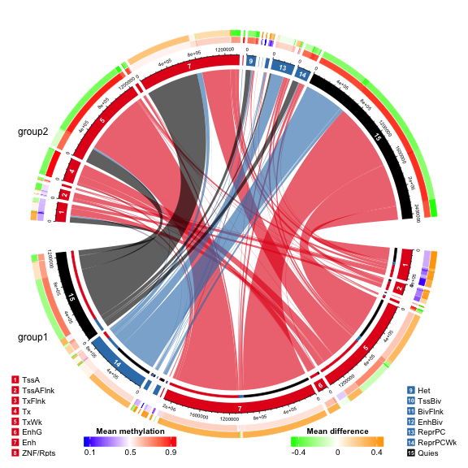